# Simulating disease transmission using differing transmission rates

Edie Bishop

13th of November 2019

# Introduction

In this script we call on a simple population dynamics model (step_deterministic_SIS), which takes a value for disease transmission rate, and a value for recovery rate, and returns a dataframe containing counts of susceptible and infection individuals. The model can be represented by the following mathematical equations:
$$S(t + 1) = S(t) - \beta * S(t) * I(t) / N + \sigma * I(t)$$
$$I(t + 1) = I(t) + \beta * S(t) * I(t) / N - \sigma * I(t)$$
*Where S = susceptible animals, I = infected animals, t = time, $\beta$ = transmission rate & $\sigma$* *= recovery rate*

### Source our functions

```r
source("0301_plot_helper.R")
source("0301_step_SIS.R")
```

### Load packages

```r
library(kableExtra, warn.conflicts = FALSE) # Allows us to build tables in the html report
library(knitr, warn.conflicts = FALSE)
library(tidyverse, warn.conflicts = FALSE) # Used to build a tibble
```

### Define parameters

To start with we define the population size and the transmission and recovery rates, in this case for E. coli infection in a herd of cattle.

```r
num.cattle <- 100
initial.infected <- 2
initial.susceptible <- num.cattle - initial.infected
```

Next we define our dataframes, herd.df.x, contian two columns: number of susceptible cattle and number of infected cattle. Each dataframe will correspond to a differnt rate of E. coli transmission.

```r
herd.df.a <- data.frame(SUSCEPTIBLES = initial.susceptible,
                      INFECTED = initial.infected)
herd.df.b <- data.frame(SUSCEPTIBLES = initial.susceptible,
                      INFECTED = initial.infected)
herd.df.c <- data.frame(SUSCEPTIBLES = initial.susceptible,
                      INFECTED = initial.infected)
herd.df.d <- data.frame(SUSCEPTIBLES = initial.susceptible,
                      INFECTED = initial.infected)
```

Then we define the transmission rate and the recovery rate for E. coli infection. We will model four different transmission rates, and assume the same recovery rate in each simulation.

```r
ecoli.transmission.a <- 1/2
ecoli.transmission.b <- 2/3
ecoli.transmission.c <- 1
ecoli.transmission.d <- 4/3
ecoli.recovery <- 1/3
```

Then we define the start time and the end time for our study, and the timesteps that we wish our model to run over.

```r
start.time <- 0
end.time <- 50
timesteps <- seq(from = start.time + 1, to = end.time)
```

### Run the function

Now we loop through the time itself (starting at the second time step). The for() command creates the loop, and then we call our function, step_deterministic_SIS(), which creates a new value for susceptiple and infected cattle at each time step. We call the funtion four times, in order to model each of the different transmission rates.

```r
for(new.time in timesteps) {
  ## Calculate the changes to the herd using or step_deterministic_SIS() function
  updated.population <- step_deterministic_SIS(latest=tail(herd.df.a, 1),
                                   transmission.rate = ecoli.transmission.a,
                                   recovery.rate = ecoli.recovery)
  ## Then define the herd.df dataframe, which is the herd.df dataframe with the updated.population
  ## dataframe appended to the end of it.
  herd.df.a <- rbind(herd.df.a, updated.population)
}
```

We need to add another column (time) to our herd.df dataframe, so that we can make a plot of population againsts time. We do this by using c() to add start.time and timesteps to the dataframe in a newly defined column below:

```r
herd.df.a$time <- c(start.time, timesteps)
```

```r
for(new.time in timesteps) {
  updated.population <- step_deterministic_SIS(latest=tail(herd.df.b, 1),
                                               transmission.rate = ecoli.transmission.b,
                                               recovery.rate = ecoli.recovery)
  herd.df.b <- rbind(herd.df.b, updated.population)
}
herd.df.b$time <- c(start.time, timesteps)
```

```r
for(new.time in timesteps) {
  updated.population <- step_deterministic_SIS(latest=tail(herd.df.c, 1),
                                               transmission.rate = ecoli.transmission.c,
                                               recovery.rate = ecoli.recovery)
  herd.df.c <- rbind(herd.df.c, updated.population)
}
herd.df.c$time <- c(start.time, timesteps)
```

```r
for(new.time in timesteps) {
  updated.population <- step_deterministic_SIS(latest=tail(herd.df.d, 1),
                                               transmission.rate = ecoli.transmission.d,
                                               recovery.rate = ecoli.recovery)
  herd.df.d <- rbind(herd.df.d, updated.population)
}
herd.df.d$time <- c(start.time, timesteps)
```

### Plotting the results

Then we can use our plot_population function to plot the herdn.df dataframe.

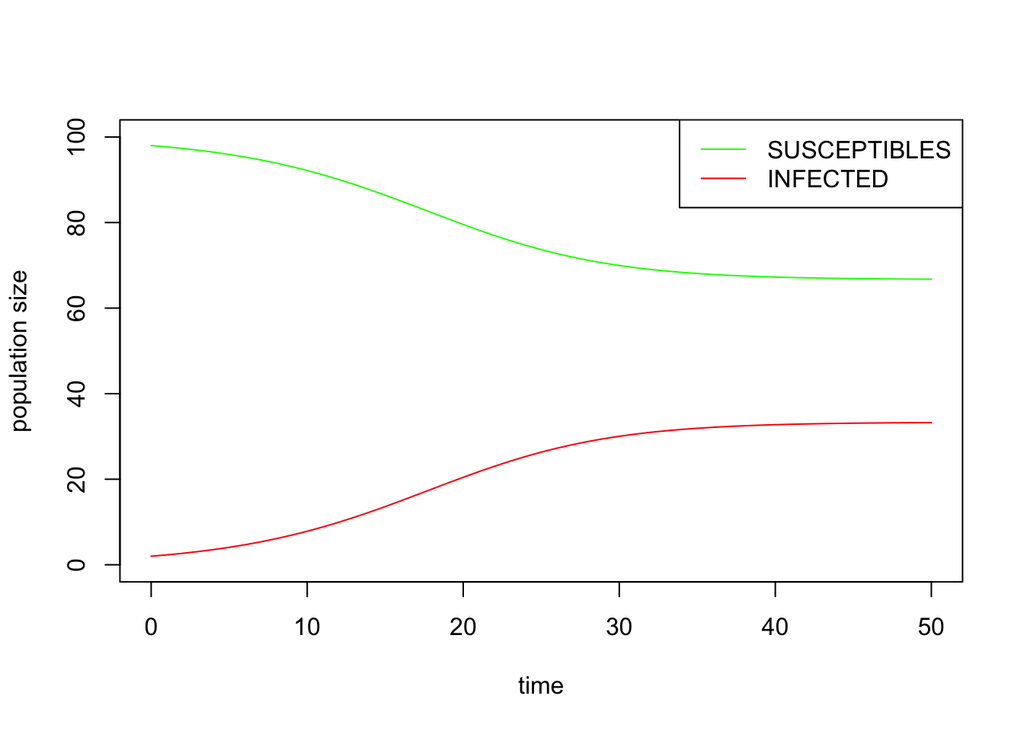

```r
plot_populations(herd.df.a, col = c("green", "red"))
```

**Figure 1** Plot of E.coli outbreak where the green line represents susceptible cattle and the red line infected cattle, assuming a transmission rate of 1/2 and a recovery rate of 1/3, over 50 weeks.

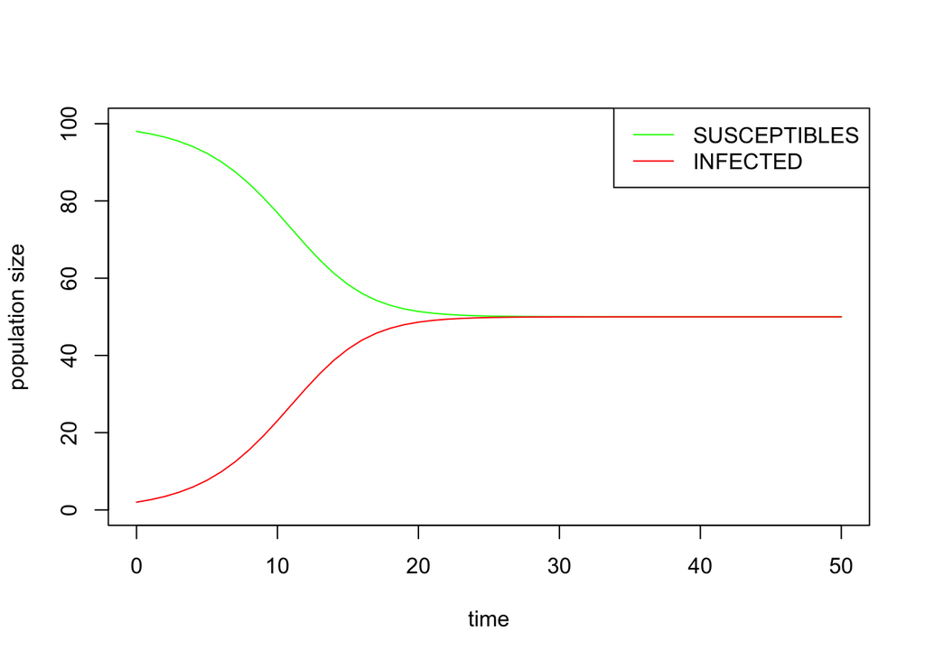

```r
plot_populations(herd.df.b, col = c("green", "red"))
```

**Figure 2** Plot of E.coli outbreak where the green line represents susceptible cattle and the red line infected cattle, assuming a transmission rate of 2/3 and a recovery rate of 1/3, over 50 weeks.

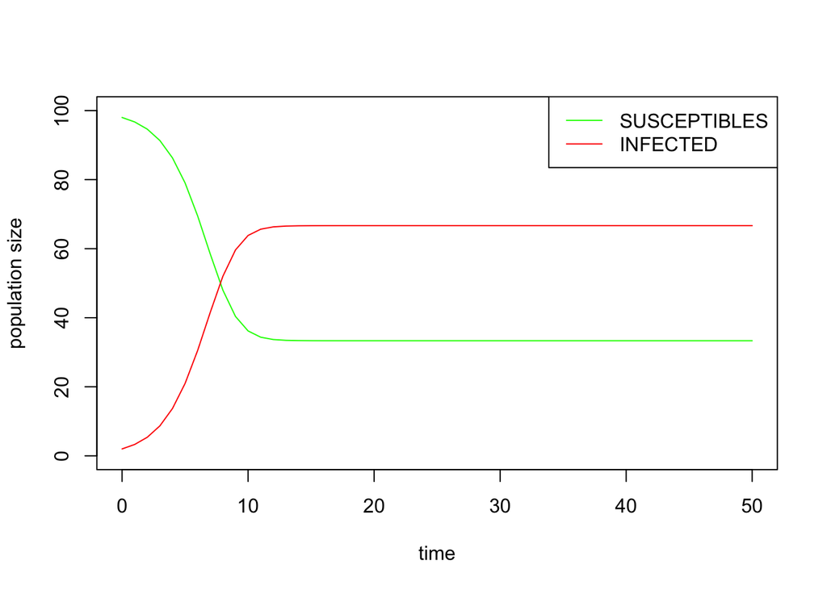

```r
plot_populations(herd.df.c, col = c("green", "red"))
```

**Figure 3** Plot of E.coli outbreak where the green line represents susceptible cattle and the red line infected cattle, assuming a transmission rate of 1 and a recovery rate of 1/3, over 50 weeks.

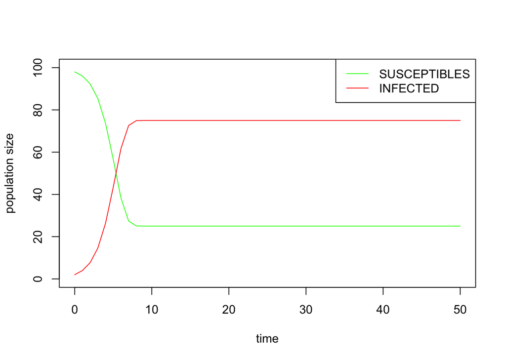

```r
plot_populations(herd.df.d, col = c("green", "red"))
```

**Figure 4** Plot of E.coli outbreak where the green line represents susceptible cattle and the red line infected cattle, assuming a transmission rate of 4/3 and a recovery rate of 1/3, over 50 weeks.

The table created below shows the transmission rates, the Basic Reproduction Number (Ro = transmission rate divided by the recovery rate), the proportion of susceptible individuals at equilibrium, and in inverse of Ro.

```r
table <- tibble("Transmission rates" = c("1/2", "2/3", "1", "4/3"),
                "Ro" = c("1.5", "2", "3", "4"),
                "Proportion susceptible at equilibrium (S/N)" = c("0.66", "0.5", "0.33", "0.25"),
               "1 / Ro" = c("2/3", "1/2", "1/3", "1/4"))

kable(table) %>%
  kable_styling(c("striped", "condensed"), full_width = F) %>%
  row_spec(0) %>%
  column_spec(1:4, width = "3cm")
```

| Transmission rates | Ro | Proportion susceptible at equilibrium (S/N) | 1 / Ro |
| --- | --- | --- | --- |
| 1/2 | 1.5 | 0.66 | 2/3 |
| 2/3 | 2 | 0.5 | 1/2 |
| 1 | 3 | 0.33 | 1/3 |
| 4/3 | 4 | 0.25 | 1/4 |